# CO2 emissions in United States

2024-02-22

## Exploratory Data Analysis

This dataset looks at Carbon Dioxide (CO2) emissions in the United States from 1973 to 2016. A large producer of CO2 is burning coal to generate electricity for the country. We would like to explore how the CO2 levels have changed over time, given its impact on the environment. Namely, CO2 absorbs heat from our planet and traps it within our atmosphere, effectively raising the global temperature. As the US and other countries have emmitted coal in increasing quantities over the years, it has had negative affects on the environment. Only more recently have organizations pushed to decrease CO2 emissions.

There are no missing values in our data.

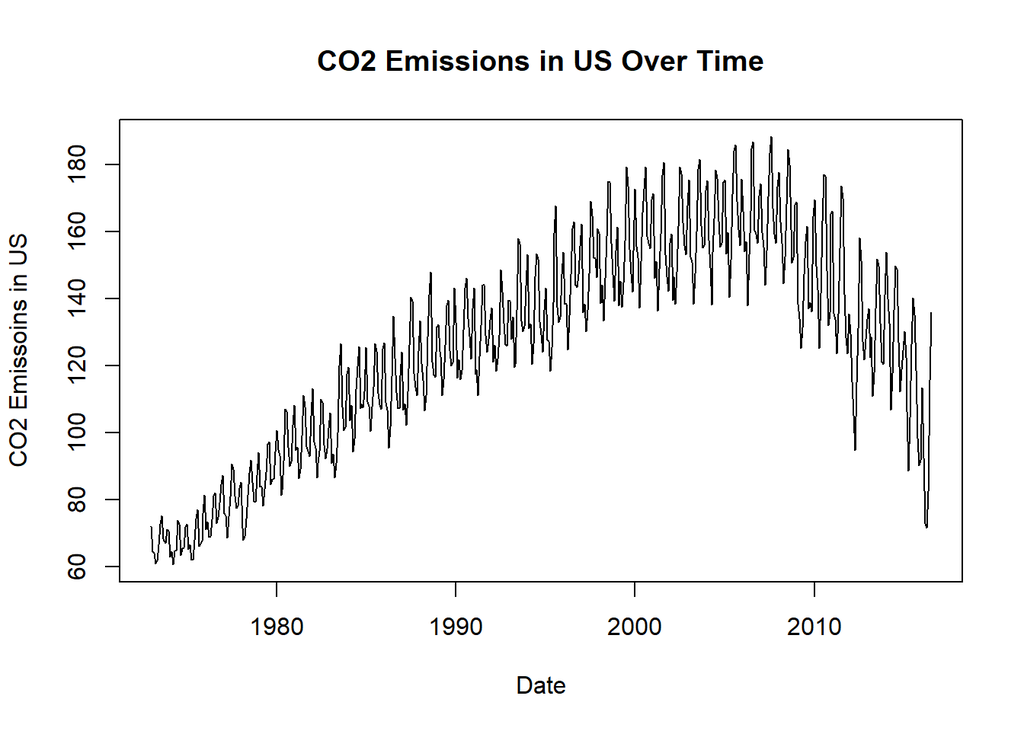

It appears as if there are two major trends over time: an increase in CO2 emissions from 1973 until approximately 2006-2008, and then a decrease in emissions after this point until 2016. It is also possible that there is annual seasonality in the CO2 emissions, which is something that we will explore.

Firstly, we need to run an ADF test to check whether the data is stationary. From the result we can see, p-value of the ADF test is 0.9627 which is much bigger than 0.05. It means that we can not reject the null hypothesis: the series is not stationary. So next we need to differentiate the data.

```
##
##  Augmented Dickey-Fuller Test
##
## data:  co2[, 2]
## Dickey-Fuller = -0.78755, Lag order = 8, p-value = 0.9627
## alternative hypothesis: stationary
```

Exploring $CO^2$ emissions summary:

```
##    Min. 1st Qu.  Median    Mean 3rd Qu.    Max.
##   60.54  102.02  129.05  125.78  151.50  188.41
```

The differenced data is now stationary:

```
##
##  Augmented Dickey-Fuller Test
##
## data:  y2
## Dickey-Fuller = -16.412, Lag order = 8, p-value = 0.01
## alternative hypothesis: stationary
```

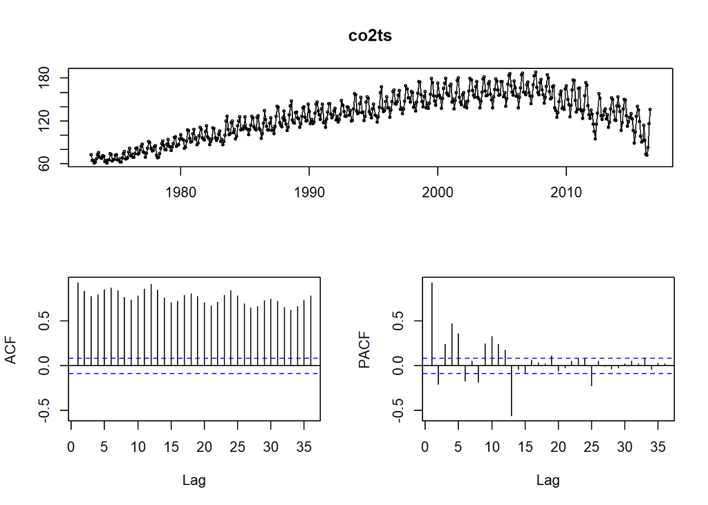

It appears that there are high levels of autocorrelation with lags going as far back as 35. It also appears that the autocorrelation fluctuates approximately every 6 lags, indicating the possibility of seasonality.

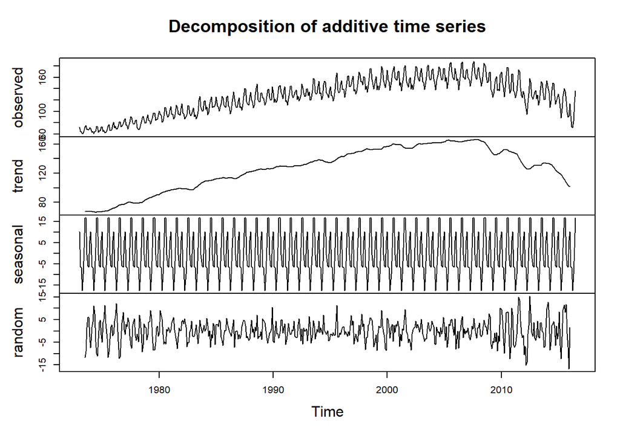

We can take a closer look at the decomposition of carbon dioxide emissions. The increasing then decreasing trend is very clear, and there is a very strong seasonal component.

## Frequency Analysis

Unsmoothed periodogram

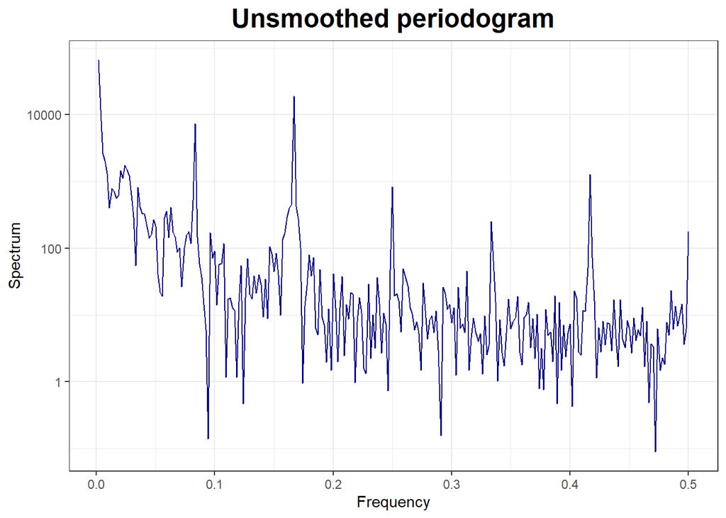

Smoothed Periodogram

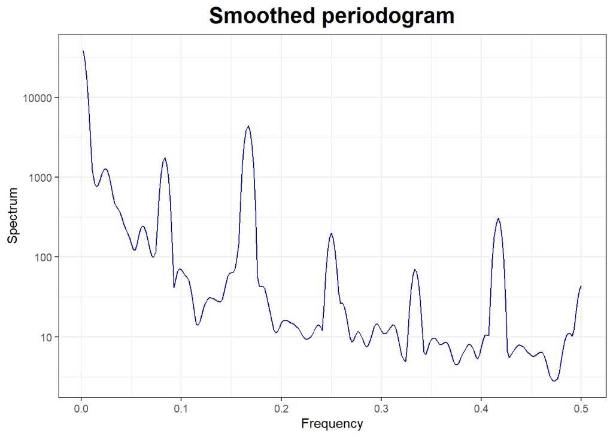

Both unsmoothed and smoothed periodograms result in dominant frequencies($\omega$) of 0.17 and 0.09

This dominant frequencies corresponds to a time period T where,

$$T= \frac{1}{\omega} = \frac{1}{0.17} =
5.88$$

Smoothed Periodogram via AR model:

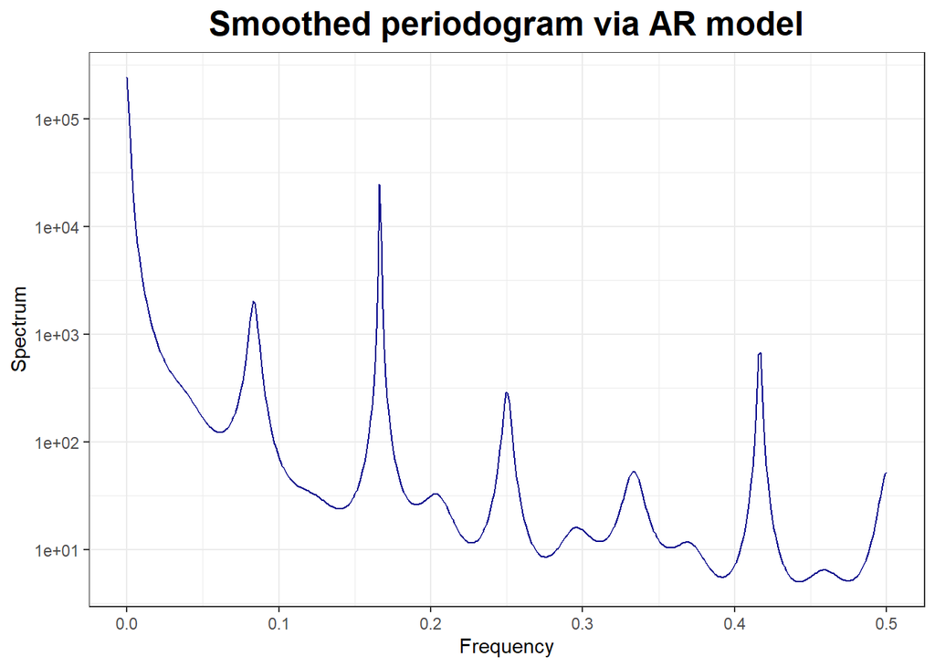

Now, the chosen ARIMA modeling approach, which incorporates these identified seasonal components, will likely yield accurate forecasts for CO2 emissions. The analysis suggests that our model will be able to project future emissions levels while considering the cyclical nature of CO2 output over time.

## Modeling

Due to the seasonal nature of our data, we have elected to use a SARIMA model, which is of the form:

$\phi(B)\Phi(B_{12})(Y_n - \mu) = \psi(B)\Psi(B_{12})\epsilon_n,$

$\text{where the error terms are a white noise process and}$

$\mu = E(Y_n)$

$\phi(x)= 1 - \phi_1x - \ldots - \phi_px^p,$

$\psi(x)= 1 + \psi_1x - \ldots + \psi_qx^q,$

$\Phi(x)= 1 - \Phi_1x - \ldots - \Phi_px^p,$

$\Psi(x)= 1 + \Psi_1x - \ldots + \Psi_qx^q.$

Then we need to decide where to start in terms of values of p and q. To choose the appropriate p, d and q, we use auto. arima function, which uses AIC as the criterion to select the most appropriate model. This analysis is conducted below:

### Model 1

```
##
##  Fitting models using approximations to speed things up...
##
##  ARIMA(2,1,2)(1,1,1)[12]                    : 2989.733
##  ARIMA(0,1,0)(0,1,0)[12]                    : 3224.131
##  ARIMA(1,1,0)(1,1,0)[12]                    : 3122.475
##  ARIMA(0,1,1)(0,1,1)[12]                    : 2997.203
##  ARIMA(2,1,2)(0,1,1)[12]                    : 2977.264
##  ARIMA(2,1,2)(0,1,0)[12]                    : Inf
##  ARIMA(2,1,2)(0,1,2)[12]                    : 2978.851
##  ARIMA(2,1,2)(1,1,0)[12]                    : 3084.412
##  ARIMA(2,1,2)(1,1,2)[12]                    : 2988.537
##  ARIMA(1,1,2)(0,1,1)[12]                    : 2976.604
##  ARIMA(1,1,2)(0,1,0)[12]                    : 3174.039
##  ARIMA(1,1,2)(1,1,1)[12]                    : 2986.237
##  ARIMA(1,1,2)(0,1,2)[12]                    : 2978.326
##  ARIMA(1,1,2)(1,1,0)[12]                    : 3083.008
##  ARIMA(1,1,2)(1,1,2)[12]                    : 2985.612
##  ARIMA(0,1,2)(0,1,1)[12]                    : 2978.552
##  ARIMA(1,1,1)(0,1,1)[12]                    : 2974.655
##  ARIMA(1,1,1)(0,1,0)[12]                    : 3159.527
##  ARIMA(1,1,1)(1,1,1)[12]                    : 2984.802
##  ARIMA(1,1,1)(0,1,2)[12]                    : 2976.428
##  ARIMA(1,1,1)(1,1,0)[12]                    : 3084.685
##  ARIMA(1,1,1)(1,1,2)[12]                    : 2983.928
##  ARIMA(1,1,0)(0,1,1)[12]                    : 3010.334
##  ARIMA(2,1,1)(0,1,1)[12]                    : 2975.512
##  ARIMA(0,1,0)(0,1,1)[12]                    : 3026.306
##  ARIMA(2,1,0)(0,1,1)[12]                    : 2993.891
##
##  Now re-fitting the best model(s) without approximations...
##
##  ARIMA(1,1,1)(0,1,1)[12]                    : 3025.322
##
##  Best model: ARIMA(1,1,1)(0,1,1)[12]
```

```
## Series: co2ts
## ARIMA(1,1,1)(0,1,1)[12]
##
## Coefficients:
##          ar1      ma1     sma1
##       0.6117  -0.8878  -0.7542
## s.e.  0.0845   0.0562   0.0312
##
## sigma^2 = 21.39:  log likelihood = -1508.62
## AIC=3025.24   AICc=3025.32   BIC=3042.18
##
## Training set error measures:
##                      ME     RMSE      MAE        MPE     MAPE     MASE
## Training set -0.2328457 4.553198 3.396243 -0.2713068 2.765444 0.537675
##                     ACF1
## Training set -0.01338409
```

We get the best model to be a Seasonal ARIMA(1,1,1)(0,1,1)[12] model, where the ARIMA part of the model has an AR(1) and MA(1) component and differenced once, and the seasonal component has an MA(1) component and differenced once. The seasonal lag is 12 months.

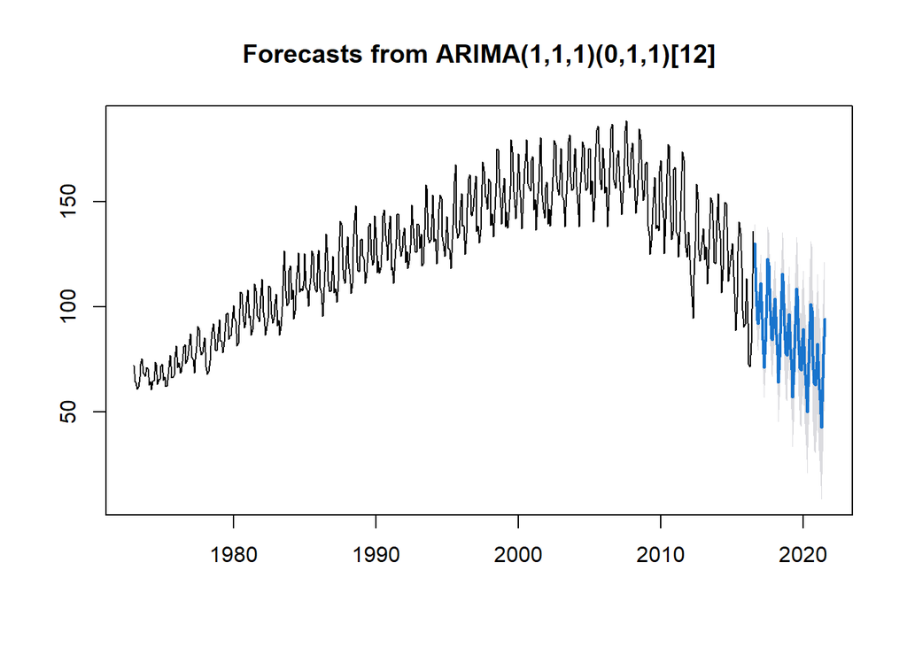

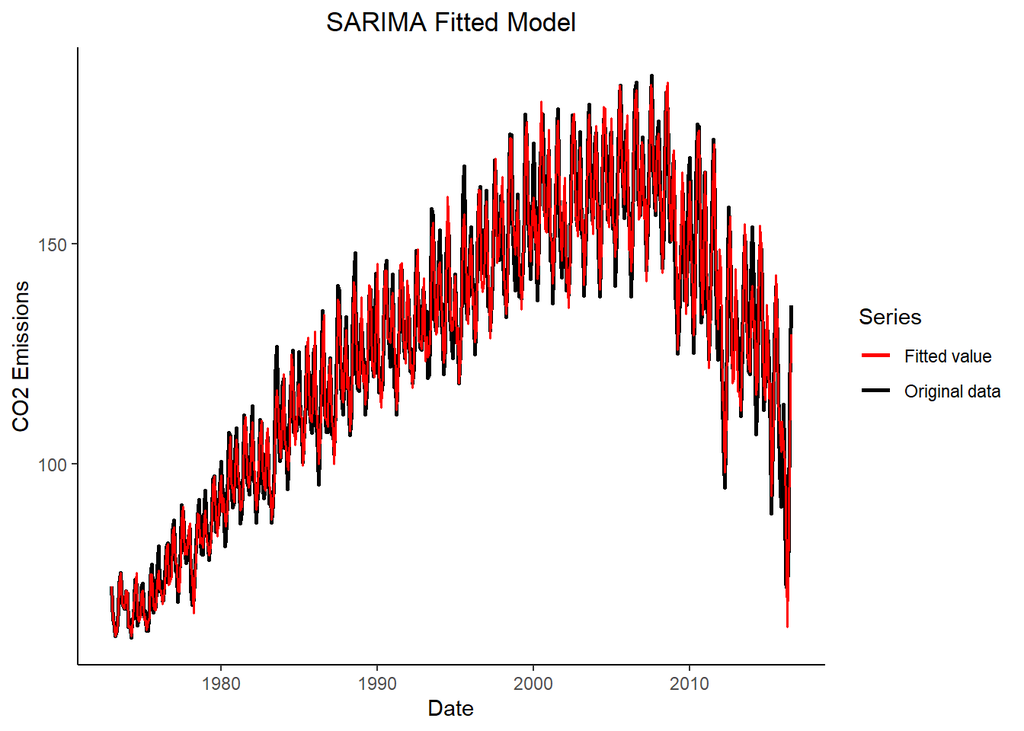

It appears that the model forecasts the CO2 emissions fairly well. The 95% confidence interval around the forecast is relatively small and it appears that the original data and fited values are similar.

### Model 2

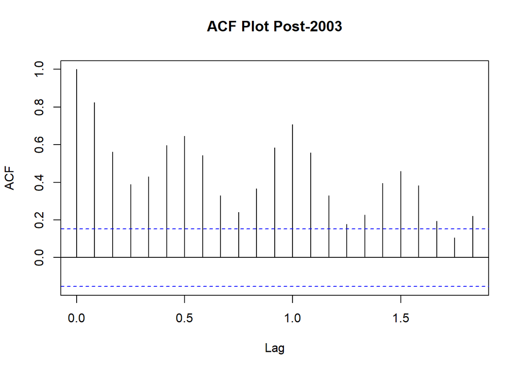

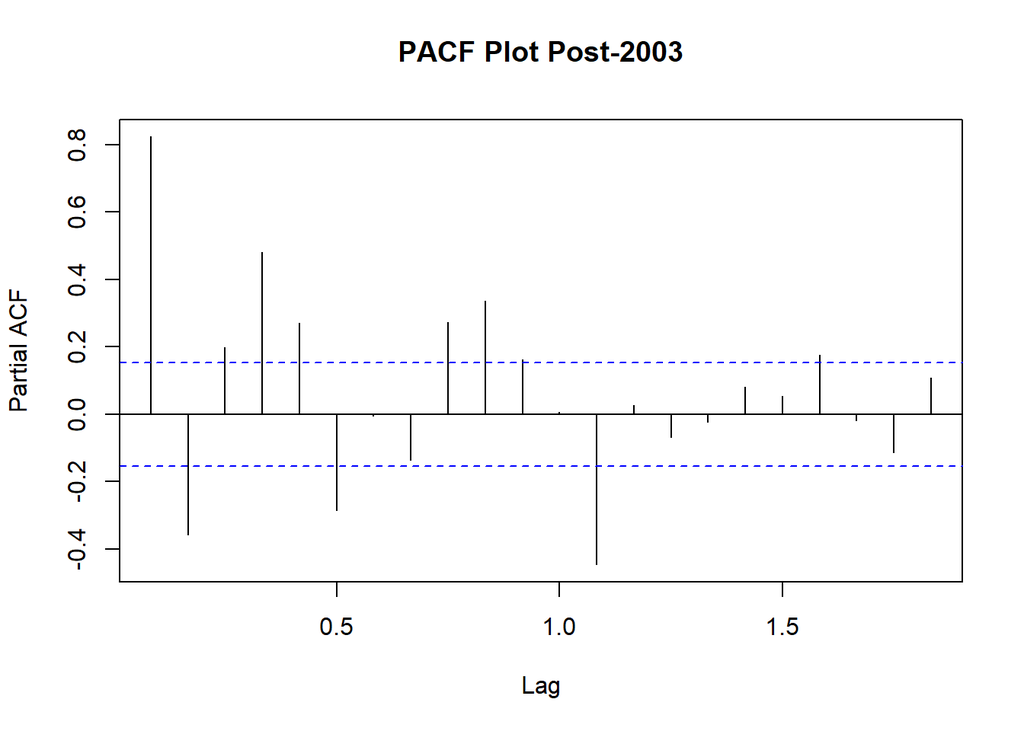

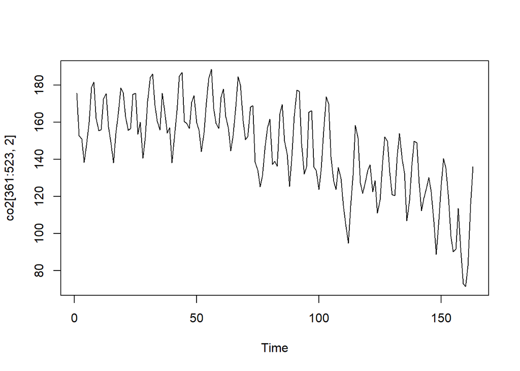

```
##
##  Augmented Dickey-Fuller Test
##
## data:  co2[361:523, 2]
## Dickey-Fuller = -4.1971, Lag order = 5, p-value = 0.01
## alternative hypothesis: stationary
```

We ran an ADF test to test for stationary, and found that the p-value was 0.01 < 0.05, meaning that we can reject the null hypothesis and the data is in fact stationary.

```
##
##  Fitting models using approximations to speed things up...
##
##  ARIMA(2,1,2)(1,1,1)[12]                    : 945.2503
##  ARIMA(0,1,0)(0,1,0)[12]                    : 972.1671
##  ARIMA(1,1,0)(1,1,0)[12]                    : 955.5193
##  ARIMA(0,1,1)(0,1,1)[12]                    : 923.154
##  ARIMA(0,1,1)(0,1,0)[12]                    : 965.7792
##  ARIMA(0,1,1)(1,1,1)[12]                    : 940.0908
##  ARIMA(0,1,1)(0,1,2)[12]                    : 923.6302
##  ARIMA(0,1,1)(1,1,0)[12]                    : 953.9603
##  ARIMA(0,1,1)(1,1,2)[12]                    : 935.9723
##  ARIMA(0,1,0)(0,1,1)[12]                    : 926.9546
##  ARIMA(1,1,1)(0,1,1)[12]                    : 923.8431
##  ARIMA(0,1,2)(0,1,1)[12]                    : 922.3506
##  ARIMA(0,1,2)(0,1,0)[12]                    : 966.841
##  ARIMA(0,1,2)(1,1,1)[12]                    : 939.8656
##  ARIMA(0,1,2)(0,1,2)[12]                    : 923.1046
##  ARIMA(0,1,2)(1,1,0)[12]                    : 955.3841
##  ARIMA(0,1,2)(1,1,2)[12]                    : 934.6264
##  ARIMA(1,1,2)(0,1,1)[12]                    : 924.038
##  ARIMA(0,1,3)(0,1,1)[12]                    : 924.4096
##  ARIMA(1,1,3)(0,1,1)[12]                    : 926.2082
##
##  Now re-fitting the best model(s) without approximations...
##
##  ARIMA(0,1,2)(0,1,1)[12]                    : 981.3449
##
##  Best model: ARIMA(0,1,2)(0,1,1)[12]
```

```
## Series: co2ts3
## ARIMA(0,1,2)(0,1,1)[12]
##
## Coefficients:
##           ma1      ma2     sma1
##       -0.1929  -0.1447  -0.7092
## s.e.   0.0828   0.0922   0.0827
##
## sigma^2 = 37.08:  log likelihood = -486.53
## AIC=981.07   AICc=981.34   BIC=993.11
##
## Training set error measures:
##                      ME     RMSE      MAE        MPE     MAPE      MASE
## Training set -0.2169387 5.782415 4.297936 -0.2912733 3.275145 0.4724278
##                      ACF1
## Training set -0.008265901
```

We select an ARIMA(0,1,2)(0,1,1)[12] to model data after 2003, based on AIC

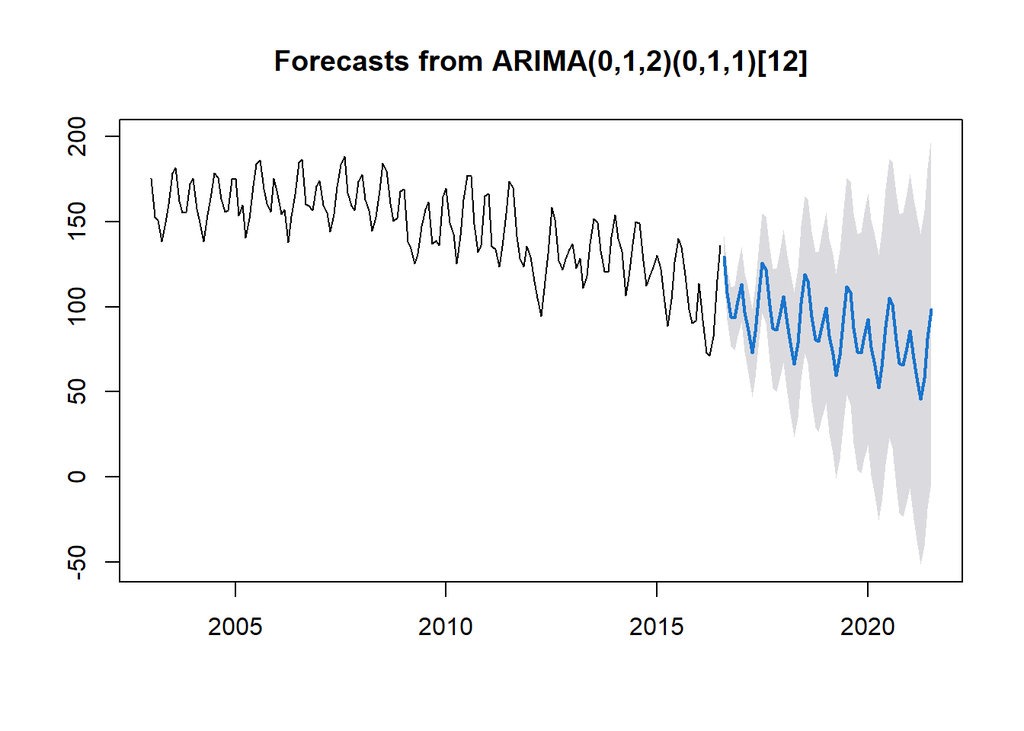

The 95% confidence interval on these predictions are much larger than with our previous model. This could be due to the fact that the model was trained using much less data.

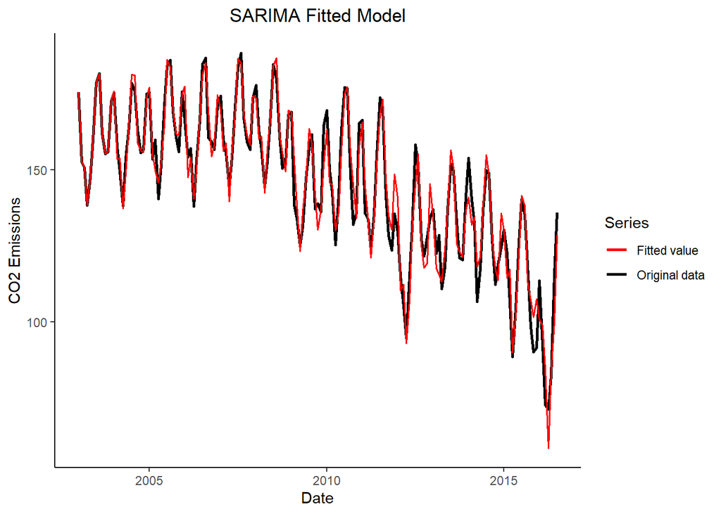

The fitted values and original data appear very similar in general.

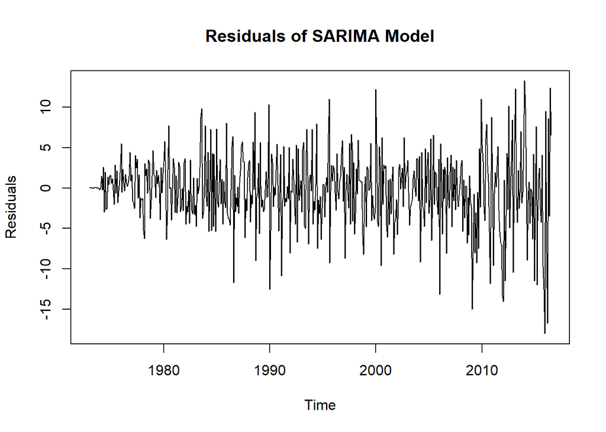

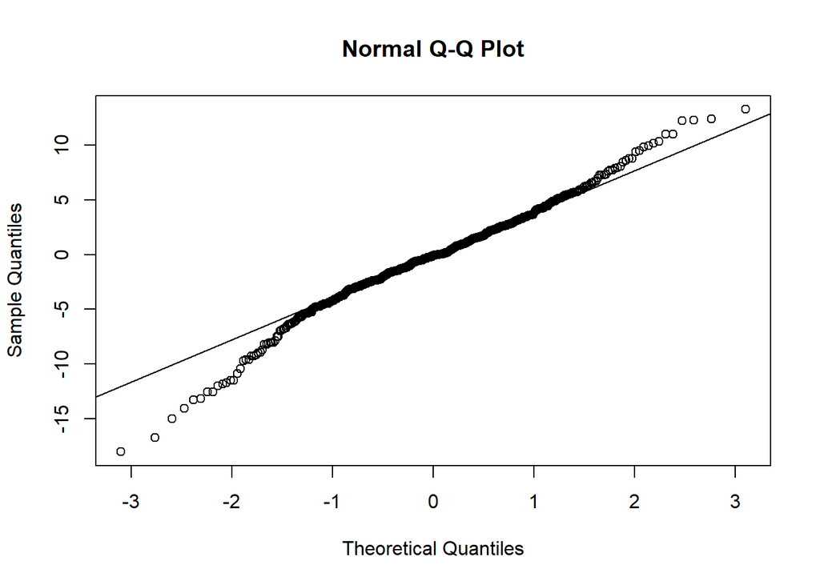

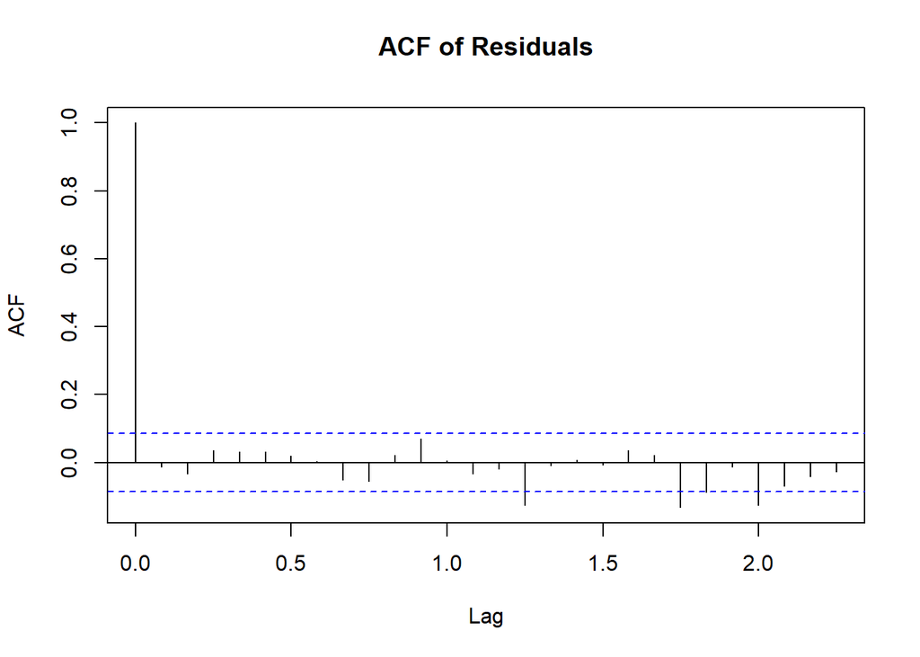

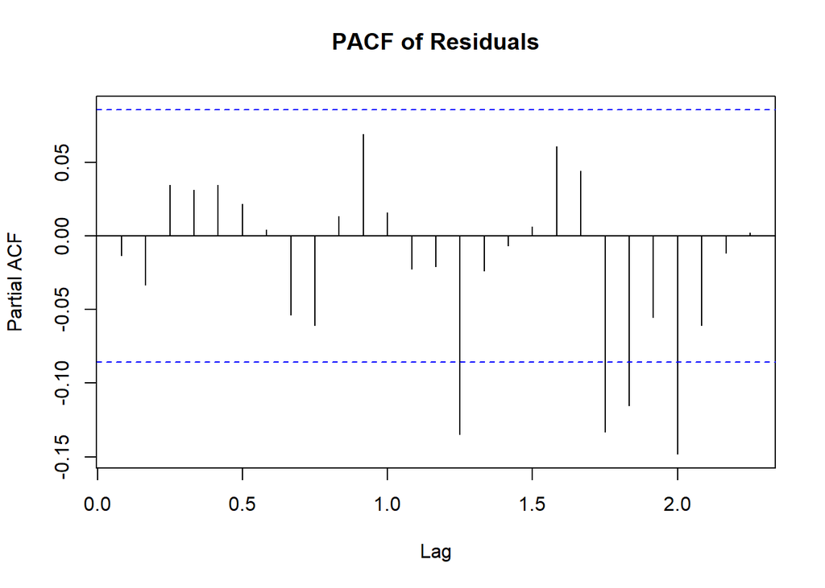

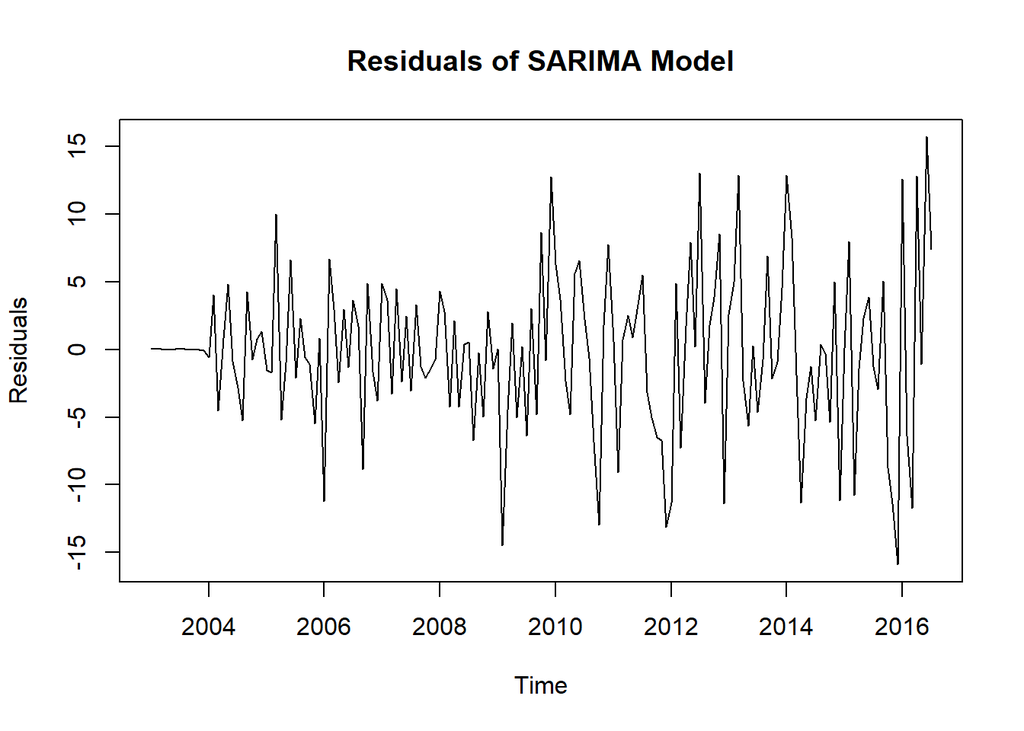

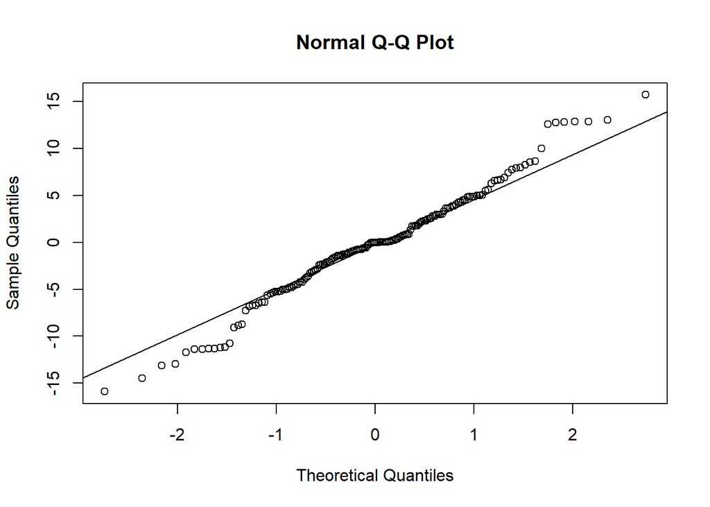

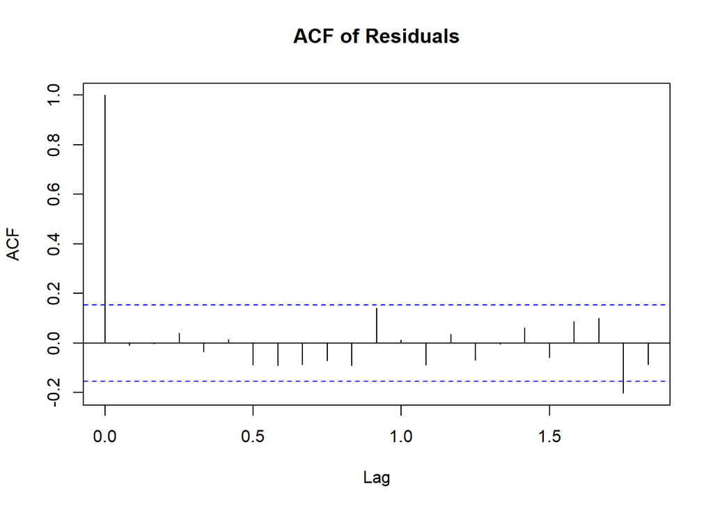

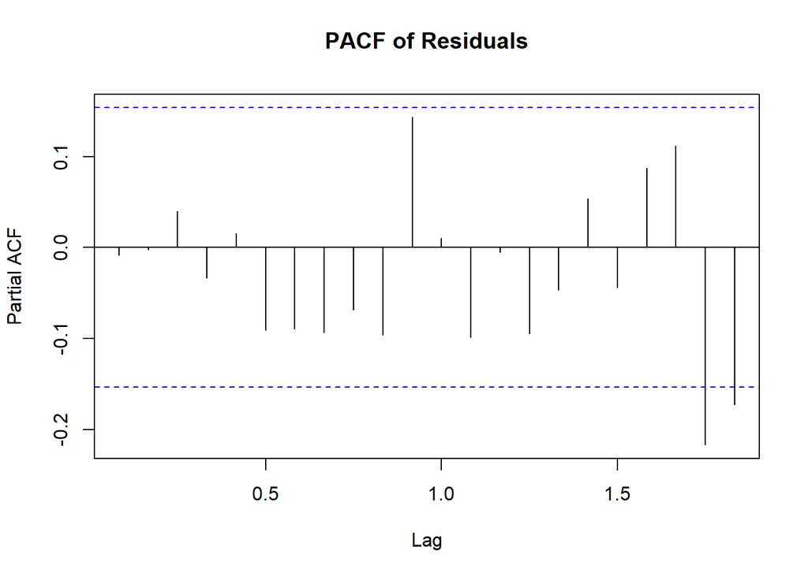

## Conclusion

From the result of auto.arima and model diagnostics, **we choose ARIMA(1,1,1)(0,1,1)[12] using the full dataset as our final model**. Although the diagnostics of this model and the model using only recent data were similar, the confidence intervals on the forecast of the first model were much smaller. We used this model to predict the co2 emission for the next 5 years. We can clearly see that carbon dioxide emissions will show a clear downward trend in the next five years, and emissions in summer and winter will still be higher than in spring and autumn, per the seasonal trend.

## References

1. Hyperparameters Configuring: R. Shumway and D. Stoffer Time Series Analysis and its Applications, 4th edition, 2017
2. Slides Chapter 6: Extending the ARMA model: Seasonality, integration and trend.
3. Slides Chapter 7: Introduction to time series analysis in the frequency domain.
4. ARIMA modelling in R https://otexts.com/fpp2/arima-r.html.
5. A Guide to Time Series Forecasting in R You Should Know https://www.simplilearn.com/tutorials/data-science-tutorial/time-series-forecasting-in-r
6. Previous project: Analysis on CO2 Emission from Natural Gas Electric Power Generation in United States